# Unsupervised_Learning_Part2

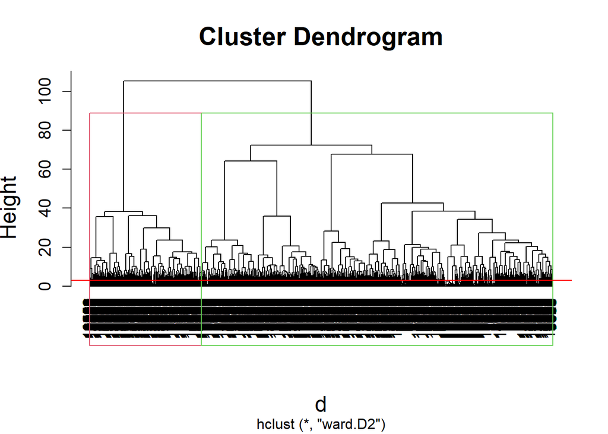

```r
#We have 2 clusters according to the Dendrogram
# see the clusters on the dendrogram using R's abline() function to draw the cut line and
# superimpose rectangular compartments for each cluster on the tree with the rect.hclust() function

options(repr.plot.width = 15, repr.plot.height = 15)
plot(res.hc, cex = 1, hang =-1, cex.main = 1.75, cex.lab=1.5, cex.axis=1.2)
rect.hclust(res.hc ,k = 2,  border = 2:5)
abline(h = 3, col = 'red')
```

Number of Records in each cluster:

```r
# find the number of records in each cluster
cut <- cutree(res.hc, k = 2)
table (cut)
```

```
## cut
##    1    2
## 2926 9192
```

*Density Based Spatial Clustering of Applications with Noise (DBSCAN)* c) Would dbscan yield better results?

In theory, yes. DBSCAN works well with data with many outliers.

Implementation

1. Obtaining the Optimal eps value

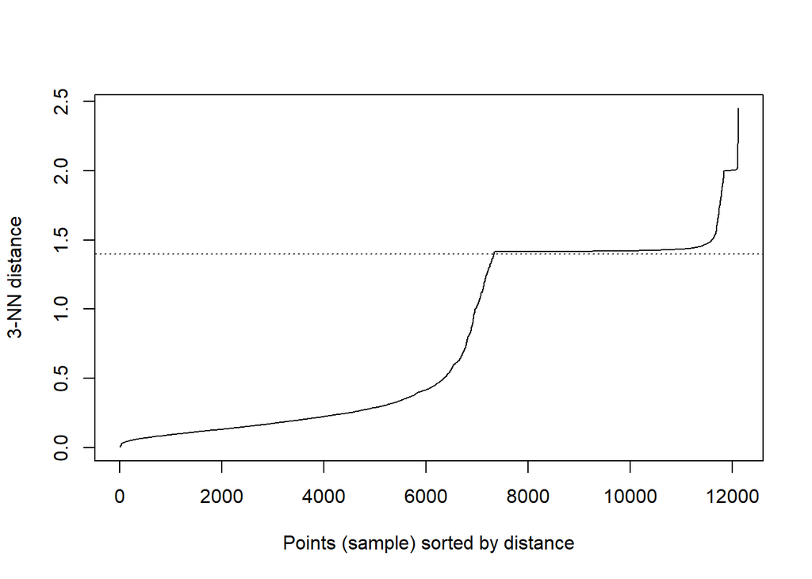

```r
kNNdistplot(norm.kira, k=3)
abline(h= 1.40, lty=3)
```

2. Applying the DBSCAN algorithm

```r
#We adjust the Minimum distance between points till we get sensible classes
dbscan.model <- dbscan(norm.kira, eps = 1.40, MinPts = 84 )

print(dbscan.model)
```

```
## dbscan Pts=12118 MinPts=84 eps=1.4
##            0  1  2   3
## border 11763  2 24   0
## seed       0 87 61 181
## total  11763 89 85 181
```

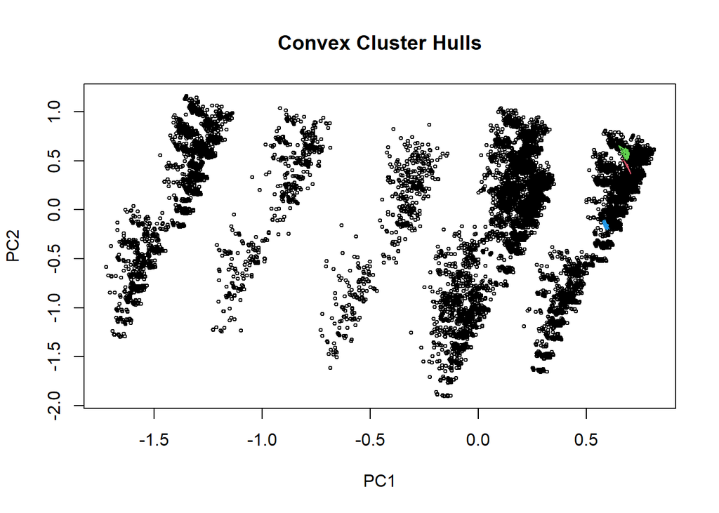

```r
#Plotting the CLusters

hullplot(norm.kira, dbscan.model$cluster)
```

```r
#0 means Noise- All those points that could not be clustered are recorded as noise
#97% of the data points are classed as noise

#CLuster 1 has 89 data points, cluster 2 has 85 data points and cluster 3 has 181 data points
```

```r
#Density Based CLustering with FPC
#set.seed(101)
#f <- fpc::dbscan(norm.kira, eps= 0.4, MinPts = 4)

#f

#CLuster Visualization
#fviz_cluster(f, norm.kira, geom ="point")
```

Follow Up Questions

1. Did we have the right data? Yes, we did.

2 Did we ask the right question? Yes, we did.

Conclusion

In this project, we sought to build an unsupervised learning model that would accurately classify the revenue attribute. Such a model would need to have accuracy levels of 95%

Unfortunately, the best our model, the K-Means algorithm could deliver is around 85%. We therefore did not meet our objective

The DBSACAN model does not perform as well as we expected

Recommendation Dimensionality Reduction - Perhaps a reduction of the dimension would allow for better generalization of the data and consequently better classification. PCA would be a potential solution